# JupyterCars

## An Exploration of the Car Quality dataset

This project seeks to analyze the car quality dataset (https://archive.ics.uci.edu/dataset/19/car+evaluation). The dataset includes 1728 observations and 7 categorical variables:

buying: buying price (vhigh, high, med, low.)  
maint: price of the maintenance (vhigh, high, med, low.)  
doors: number of doors (2, 3, 4, 5more)  
persons: capacity in terms of persons to carry (2, 4, more)  
lug_boot: the size of luggage boot (small, med, big)  
safety: estimated safety of the car (low, med, high)  
class: evaulation level (unacceptable, acceptable, good, very good)

This project seeks to test and tune multiple machine learning models to predict a car's evaluation level given the other features.

Here are the libraries used in this analysis:

```python
import numpy as np
import pandas as pd
import matplotlib.pyplot as plt
from sklearn.model_selection import train_test_split
from sklearn.ensemble import RandomForestClassifier
from sklearn.neighbors import KNeighborsClassifier
from sklearn.linear_model import LogisticRegression
from sklearn.neural_network import MLPClassifier
from sklearn.metrics import confusion_matrix, ConfusionMatrixDisplay, classification_report
```

## Exploring our dataset

First, we import our dataset. There are several ways to do this, but in this instance, I have it stored locally on my device. This dataset does not already come with column names, so we must add them ourselves. Since all of our variables are categorical, we do not need to scale our data, but we do need to use One-Hot Encodind. We also want to split our dataset into test, training and validation groups.

```python
#importing our dataset
cols = ["buying", "maint", "doors", "persons", "lug_boot", "safety", "class"]
cars = pd.read_csv("car.data", header=None, names = cols)

print(cars.shape)
#split into X and y
cars_X = cars.iloc[:,:-1]
cars_y = cars.iloc[:,-1]
print(cars_X.head(), cars_y.head())

# use one hot encoding for our x variables, all of which are categorical.
cars_X = pd.get_dummies(cars_X)



#splitting our data into test, training, and validation sets.
X_main, X_test, y_main, y_test = train_test_split(cars_X, cars_y, test_size=0.2, random_state = 0)
X_train, X_val, y_train, y_val = train_test_split(X_main, y_main, test_size= 0.2, random_state = 0)
```

```
(1728, 7)
  buying  maint doors persons lug_boot safety
0  vhigh  vhigh     2       2    small    low
1  vhigh  vhigh     2       2    small    med
2  vhigh  vhigh     2       2    small   high
3  vhigh  vhigh     2       2      med    low
4  vhigh  vhigh     2       2      med    med 0    unacc
1    unacc
2    unacc
3    unacc
4    unacc
Name: class, dtype: object
```

Now let's see how our data is distributed across our dataset, mainly for our y-value: Car quality. This is important since we are making a classification engine so we have an idea of idea of what kind of data our engine would be training and testing on. For example, we can see that there is a very high number of "unnaceptable" quality cars, and not very many "good" or "very good" ones. If we train and test a model on our data, we can expect similar results in our classification model.

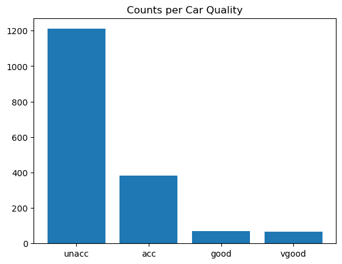

```python
# Visualizing the categorizations of our y value (quality)
qual_count = cars["class"].value_counts()

fig, ax = plt.subplots()
ax.bar(qual_count.index, qual_count.values)
ax.plot()
plt.title("Counts per Car Quality")
plt.show()
```

Now we're ready to make some models. To start, let's try out four different models and test their performance: Logistic Regression, Random Forest, a K neighbors Classifier, and a Neural Network Classifier. If we make preliminary models and their respective confusion matrices and classification reports, we can see that all four do a good job of predicting car quality, although the Neural Network and Random Forest do have observably better performance. As predicted, our validation contains a high amount of unacceptable quality cars, and all of our models have high f-1 scores for this classification, with the lowest one being 0.95 for the KNN Classifier. The models do less of a good job of predicting when a car is good and very good with only the Neural network reaching high f1 scores for that category. This is also very like due to the small number of good and very good cars we have in our sample; in this example, we only have 15 "good" quality cars in our validation set. This is still a very strong starting point, however. When determining car quality, it is important to identify if a car is not up to quality for safety and road regulations, and our models are strong in this regard.

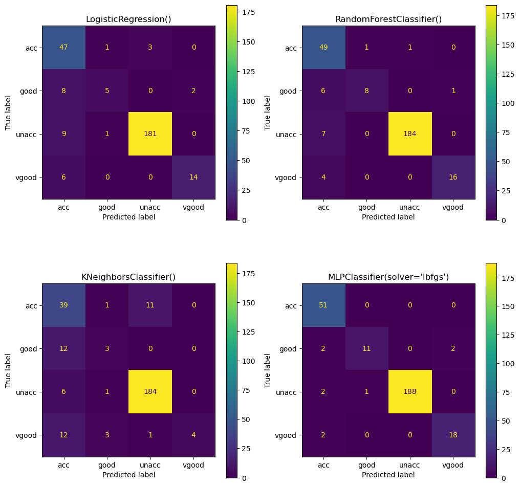

```python
# Our models and target baels
labels = ["unacc","acc","good","vgood"]
models = [LogisticRegression(), RandomForestClassifier(), KNeighborsClassifier(), MLPClassifier(solver = "lbfgs")]
axes = [(0,0),(0,1),(1,0),(1,1)]

#Plotting our confusuion matrices
fig, ax = plt.subplots(2,2, figsize = (12,12))
for a, model in zip(axes, models):
    clf = model
    clf.fit(X_train, y_train)
    y_pred = clf.predict(X_val)
    cm = confusion_matrix(y_val, y_pred)
    cm_disp = ConfusionMatrixDisplay(cm,  display_labels= ["acc", "good", "unacc", "vgood"])
    cm_disp.plot(ax = ax[a[0],a[1]])
    cm_disp.ax_.set_title(model)

plt.show()
```

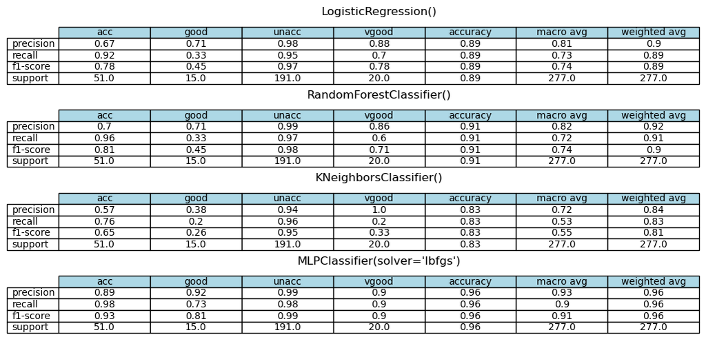

```python
fig, ax = plt.subplots(len(models),1, figsize = (12,6))
for i, model in enumerate(models):
    clf = model
    clf.fit(X_train, y_train)
    y_pred = clf.predict(X_val)
    report = classification_report(y_val, y_pred, output_dict=True)
    df = pd.DataFrame(report)
    df = df.round(2)
    ax[i].axis('off')
    ax[i].set_title(model)
    table = pd.plotting.table(ax[i],df,
                loc='center',
                cellLoc='center',
                colColours=['lightblue']*7
                )
plt.show()
```

For this project, I chose to test the hyperparameters for our Neural Network to optimize the model. There are several ways to approach doing this. Suppose we are a car dealership and we want to sell only the highest qality cars possible and therefore make very sure we do not have any "unacceptable" cars in our selection. This means we want to have high recall regarding unacceptable quality cars to ensure we do not accidentally sell a faulty vehicle. On the other hand, if we were a consumer who wanted to view a wide market of cars, having precision is important so we do not accidentally exclude our potential dream vehicle. Fortunately, our Neural Network has both high precision and recall, so it serves as a great starting point for our model. Let's start by testing how our model performs with different layer sizes and iterations. The following code below tests our neural networks from a depth from 25 to 250, and a width of 5 to 50. We might get some warnings thrown for some of our smaller Neural Networks failing to converge.

[output not shown]

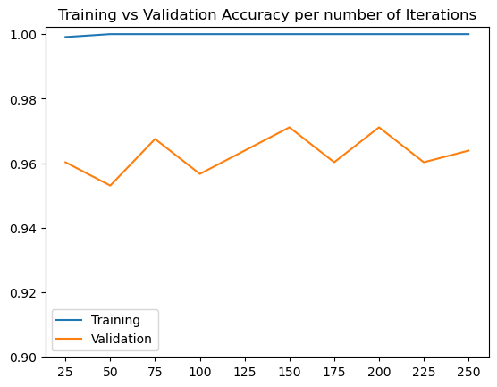

[output not shown]

[figure not shown]

```python
depth = [25*i for i in range(1,11)]
width = [5*i for i in range(1,11)]
train_acc = [0]*len(depth)
val_acc = [0]*len(depth)

for i, d in enumerate(depth):
    NN_clf = MLPClassifier(max_iter=d, solver="lbfgs")
    NN_clf.fit(X_train, y_train)
    train_acc[i] = NN_clf.score(X_train, y_train)
    val_acc[i] = (NN_clf.score(X_val, y_val))

fig, ax = plt.subplots()
ax.plot(depth,train_acc)
ax.plot(depth,val_acc)
ax.legend(labels = ["Training", "Validation"])
plt.title("Training vs Validation Accuracy per number of Iterations")
plt.xticks(depth)
plt.ylim(0.9,)
plt.show()

for w in width:
    NN_clf = MLPClassifier(max_iter = 200, hidden_layer_sizes = (w,), solver="lbfgs")
    NN_clf.fit(X_train, y_train)
    train_acc[i] = NN_clf.score(X_train, y_train)
    val_acc[i] = NN_clf.score(X_val, y_val)


fig, ax = plt.subplots()
ax.plot(width,train_acc)
ax.plot(width,val_acc)
ax.legend(labels = ["Training", "Validation"])
plt.title("Training vs Validation Accuracy per number of\n Nodes per Hidden Layer (With a depth of 200)")
plt.xticks(width)
plt.ylim(0.9,)
plt.show()
```

Eveutually I settled with a hidden layer size of 30 and a maximum interations of 200. Testing our final model on our test data, we get promising results with high accuracies and f-1 scores across all categories. Even with target labels such as "good" and "very good" we can see high precision and recall.

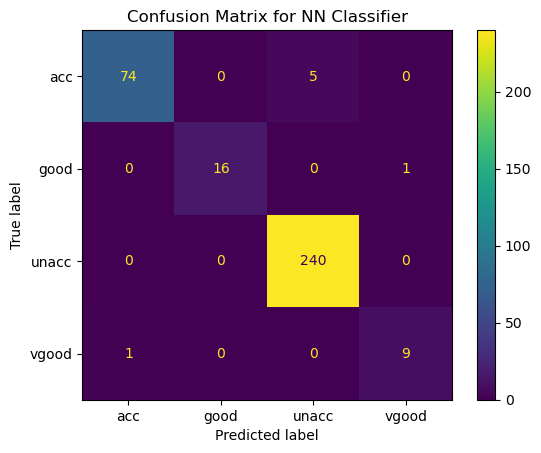

```
             acc   good   unacc  vgood  accuracy  macro avg  weighted avg
precision   0.99   1.00    0.98    0.9      0.98       0.97          0.98
recall      0.94   0.94    1.00    0.9      0.98       0.94          0.98
f1-score    0.96   0.97    0.99    0.9      0.98       0.96          0.98
support    79.00  17.00  240.00   10.0      0.98     346.00        346.00
```

```python
final_clf = MLPClassifier(hidden_layer_sizes=30,max_iter=200, solver="lbfgs")
final_clf.fit(X_train,y_train)
y_pred = final_clf.predict(X_test)


fig, ax = plt.subplots()
report = classification_report(y_test, y_pred, output_dict=True)
cm = confusion_matrix(y_test, y_pred)
cm_disp = ConfusionMatrixDisplay(cm, display_labels= ["acc", "good", "unacc", "vgood"])
cm_disp.plot(ax = ax)
cm_disp.ax_.set_title("Confusion Matrix for NN Classifier")
plt.show()
#cm_disp.im_.colorbar.remove()
df = pd.DataFrame(report)
df = df.round(2)
print(df)
```

Overall, this model is an accurate predictor for car quality given the listed features: buying price, maintenance, number of doors, maximum occupancy, luggage size, and safety, and it is especially effective in predicting cars of unacceptable quality, with an f-1 score of 0.99 on our test group. One of the drawbacks of this model however is that the dataset it was trained on was relatively small with only about 1700 observations. Given the number of cars in circulation, this is only an extremely small portion of the total population, so this model might not hold up as well when tested against larger sets of data. Further exploration of this dataset could include tuning the Random Forest Classifer or fitting a new models such as a single Decision tree or Support Vector Classification Engine.

A decision tree or random forest might not perform as accurately as our Neural Network, but will be more interpretable and more easily explainable than the "black box" the neural network provides. Depending on the situation, it might be preferable to sacrifce a small amount of accuracy for this simplicity. For example, if you were to provide a model for shareholders or a car dealership unfamiliar with machine learning methods, a decision tree would allow them to understand, use, and even tune the model if needed.